# Cars4U - Landon Gray

# Problem Definition

### Problem Statement¶

The problem at hand is to explore and visualize the data set and to build a linear regression model that will help predict the prices of used cars to help the business appropriately price vehicles to be sold in the used car market.

### Data Information

Attribute Information :

- S.No.: Serial number
- Name: Name of the car which includes brand name and model name
- Location: Location in which the car is being sold or is available for purchase (cities)
- Year: Manufacturing year of the car
- Kilometers_driven: The total kilometers (a unit used to measure length or distance) driven in the car by the previous owner(s)
- Fuel_Type: The type of fuel used by the car (Petrol, Diesel, Electric, CNG, LPG)
- Transmission: The type of transmission used by the car (Automatic/Manual)
- Owner: Type of ownership
- Mileage: The standard mileage offered by the car company in kmpl or km/kg
- Engine: The displacement volume of the engine in CC
- Power: The maximum power of the engine in bhp
- Seats: The number of seats in the car
- New_Price: The price of a new car of the same model in INR Lakhs (1 Lakh INR = 100,000 INR)
- Price: The price of the used car in INR Lakhs

### Import Necessary Libraries

```python
# Libraries to help with reading and manipulating data
import numpy as np
import pandas as pd

# Libraries to help with data visualization
import matplotlib.pyplot as plt
import seaborn as sns

# to split the data into train and test
from sklearn.model_selection import train_test_split

# to build linear regression_model
from sklearn.linear_model import LinearRegression

# to check model performance
from sklearn.metrics import mean_squared_error


# to check model performance
from sklearn.metrics import mean_absolute_error, mean_squared_error, r2_score

# remove limits from max diplayed columns and rows
pd.set_option('display.max_columns', None)
pd.set_option('display.max_rows', None)
```

### Load the dataset

```python
data = pd.read_csv("used_cars_data.csv")
df = data.copy() # duplicate the data so that the original data frame remains unchanged.
df.head()
```

|  | S.No. | Name | Location | Year | Kilometers_Driven | Fuel_Type | Transmission | Owner_Type | Mileage | Engine | Power | Seats | New_Price | Price |
| --- | --- | --- | --- | --- | --- | --- | --- | --- | --- | --- | --- | --- | --- | --- |
| 0 | 0 | Maruti Wagon R LXI CNG | Mumbai | 2010 | 72000 | CNG | Manual | First | 26.6 km/kg | 998 CC | 58.16 bhp | 5.0 | 5.51 | 1.75 |
| 1 | 1 | Hyundai Creta 1.6 CRDi SX Option | Pune | 2015 | 41000 | Diesel | Manual | First | 19.67 kmpl | 1582 CC | 126.2 bhp | 5.0 | 16.06 | 12.50 |
| 2 | 2 | Honda Jazz V | Chennai | 2011 | 46000 | Petrol | Manual | First | 18.2 kmpl | 1199 CC | 88.7 bhp | 5.0 | 8.61 | 4.50 |
| 3 | 3 | Maruti Ertiga VDI | Chennai | 2012 | 87000 | Diesel | Manual | First | 20.77 kmpl | 1248 CC | 88.76 bhp | 7.0 | 11.27 | 6.00 |
| 4 | 4 | Audi A4 New 2.0 TDI Multitronic | Coimbatore | 2013 | 40670 | Diesel | Automatic | Second | 15.2 kmpl | 1968 CC | 140.8 bhp | 5.0 | 53.14 | 17.74 |

```python
#check for duplicate data
df.duplicated().sum()
```

```
0
```

### Observe the shape of the data

```python
# rows and columns
df.shape
```

```
(7253, 14)
```

### Observe datatypes of data columns

```python
df.info()
```

```
<class 'pandas.core.frame.DataFrame'>
RangeIndex: 7253 entries, 0 to 7252
Data columns (total 14 columns):
 #   Column             Non-Null Count  Dtype
---  ------             --------------  -----
 0   S.No.              7253 non-null   int64
 1   Name               7253 non-null   object
 2   Location           7253 non-null   object
 3   Year               7253 non-null   int64
 4   Kilometers_Driven  7253 non-null   int64
 5   Fuel_Type          7253 non-null   object
 6   Transmission       7253 non-null   object
 7   Owner_Type         7253 non-null   object
 8   Mileage            7251 non-null   object
 9   Engine             7207 non-null   object
 10  Power              7078 non-null   object
 11  Seats              7200 non-null   float64
 12  New_Price          7253 non-null   float64
 13  Price              6019 non-null   float64
dtypes: float64(3), int64(3), object(8)
memory usage: 793.4+ KB
```

### Statistical summary of data

```python
df.describe(include="all").T
```

|  | count | unique | top | freq | mean | std | min | 25% | 50% | 75% | max |
| --- | --- | --- | --- | --- | --- | --- | --- | --- | --- | --- | --- |
| S.No. | 7253.0 | NaN | NaN | NaN | 3626.0 | 2093.905084 | 0.0 | 1813.0 | 3626.0 | 5439.0 | 7252.0 |
| Name | 7253 | 2041 | Mahindra XUV500 W8 2WD | 55 | NaN | NaN | NaN | NaN | NaN | NaN | NaN |
| Location | 7253 | 11 | Mumbai | 949 | NaN | NaN | NaN | NaN | NaN | NaN | NaN |
| Year | 7253.0 | NaN | NaN | NaN | 2013.365366 | 3.254421 | 1996.0 | 2011.0 | 2014.0 | 2016.0 | 2019.0 |
| Kilometers_Driven | 7253.0 | NaN | NaN | NaN | 58699.063146 | 84427.720583 | 171.0 | 34000.0 | 53416.0 | 73000.0 | 6500000.0 |
| Fuel_Type | 7253 | 5 | Diesel | 3852 | NaN | NaN | NaN | NaN | NaN | NaN | NaN |
| Transmission | 7253 | 2 | Manual | 5204 | NaN | NaN | NaN | NaN | NaN | NaN | NaN |
| Owner_Type | 7253 | 4 | First | 5952 | NaN | NaN | NaN | NaN | NaN | NaN | NaN |
| Mileage | 7251 | 450 | 17.0 kmpl | 207 | NaN | NaN | NaN | NaN | NaN | NaN | NaN |
| Engine | 7207 | 150 | 1197 CC | 732 | NaN | NaN | NaN | NaN | NaN | NaN | NaN |
| Power | 7078 | 385 | 74 bhp | 280 | NaN | NaN | NaN | NaN | NaN | NaN | NaN |
| Seats | 7200.0 | NaN | NaN | NaN | 5.279722 | 0.81166 | 0.0 | 5.0 | 5.0 | 5.0 | 10.0 |
| New_Price | 7253.0 | NaN | NaN | NaN | 21.307322 | 24.256314 | 3.91 | 7.88 | 11.3 | 21.69 | 375.0 |
| Price | 6019.0 | NaN | NaN | NaN | 9.479468 | 11.187917 | 0.44 | 3.5 | 5.64 | 9.95 | 160.0 |

# Exploring Data and Preprocessing

### Explore missing values

```python
df.isnull().sum().sort_values(ascending=False)
```

```
Price                1234
Power                 175
Seats                  53
Engine                 46
Mileage                 2
S.No.                   0
Name                    0
Location                0
Year                    0
Kilometers_Driven       0
Fuel_Type               0
Transmission            0
Owner_Type              0
New_Price               0
dtype: int64
```

```python
# examine a few random rows
df.sample(n=10)
```

|  | S.No. | Name | Location | Year | Kilometers_Driven | Fuel_Type | Transmission | Owner_Type | Mileage | Engine | Power | Seats | New_Price | Price |
| --- | --- | --- | --- | --- | --- | --- | --- | --- | --- | --- | --- | --- | --- | --- |
| 3927 | 3927 | Maruti Ciaz Alpha | Mumbai | 2017 | 19416 | Petrol | Manual | First | 21.56 kmpl | 1462 CC | 103.25 bhp | 5.0 | 11.560 | 8.25 |
| 3886 | 3886 | Toyota Etios VX | Coimbatore | 2016 | 33415 | Petrol | Manual | First | 16.78 kmpl | 1496 CC | 88.73 bhp | 5.0 | 8.525 | 6.58 |
| 5284 | 5284 | Toyota Fortuner 4x2 AT | Jaipur | 2015 | 100000 | Diesel | Automatic | First | 12.55 kmpl | 2982 CC | 168.5 bhp | 7.0 | 37.170 | 19.00 |
| 7243 | 7243 | Renault Duster 85PS Diesel RxL | Chennai | 2015 | 70000 | Diesel | Manual | First | 19.87 kmpl | 1461 CC | 83.8 bhp | 5.0 | 15.050 | NaN |
| 634 | 634 | Hyundai i20 Sportz Option | Delhi | 2013 | 48454 | Petrol | Manual | Second | 17.0 kmpl | 1197 CC | 80 bhp | 5.0 | 10.250 | 3.50 |
| 4124 | 4124 | Honda City V MT | Pune | 2013 | 100000 | Petrol | Manual | First | 16.8 kmpl | 1497 CC | 116.3 bhp | 5.0 | 13.580 | 6.25 |
| 5498 | 5498 | Mahindra Scorpio 2.6 SLX CRDe | Hyderabad | 2006 | 92000 | Diesel | Manual | First | 10.5 kmpl | 2179 CC | 120 bhp | 8.0 | 18.865 | 3.45 |
| 6664 | 6664 | BMW 5 Series 2013-2017 530d M Sport | Bangalore | 2015 | 16000 | Diesel | Automatic | First | 14.69 kmpl | 2993 CC | 258 bhp | 5.0 | 67.870 | NaN |
| 1479 | 1479 | Maruti Swift VXI Optional | Kochi | 2017 | 42527 | Petrol | Manual | First | 20.4 kmpl | 1197 CC | 81.80 bhp | 5.0 | 7.880 | 5.27 |
| 5361 | 5361 | Maruti A-Star AT VXI | Hyderabad | 2013 | 56500 | Petrol | Automatic | First | 16.98 kmpl | 998 CC | 66.1 bhp | 5.0 | 7.880 | 3.45 |

Looking at 10 random values gives me a snapshot of what I am looking at. We'll drop a few colums including S.NO. Which appears to be an id. The name model looks useful for feature engineering, we can derive the make and model from this column and strip out the irrelavent data we don't need.

Some of the columns arent in numeric form and have strings in them. Example Milage, Engine and Power. We want to remove the units string so we can treat these values as numeric.

Transmission, Fuel Type and Location appear to be categorial.

```python
# price is the dependent variable we can drop those since we won't be able to do predictions against these rows
df = df[df['Price'].notna()]

df.isnull().sum().sort_values(ascending=False)
```

```
Power                143
Seats                 42
Engine                36
Mileage                2
S.No.                  0
Name                   0
Location               0
Year                   0
Kilometers_Driven      0
Fuel_Type              0
Transmission           0
Owner_Type             0
New_Price              0
Price                  0
dtype: int64
```

```python
df[df['Seats'].isna()]
```

|  | S.No. | Name | Location | Year | Kilometers_Driven | Fuel_Type | Transmission | Owner_Type | Mileage | Engine | Power | Seats | New_Price | Price |
| --- | --- | --- | --- | --- | --- | --- | --- | --- | --- | --- | --- | --- | --- | --- |
| 194 | 194 | Honda City 1.5 GXI | Ahmedabad | 2007 | 60006 | Petrol | Manual | First | 0.0 kmpl | NaN | NaN | NaN | 13.580 | 2.95 |
| 208 | 208 | Maruti Swift 1.3 VXi | Kolkata | 2010 | 42001 | Petrol | Manual | First | 16.1 kmpl | NaN | NaN | NaN | 7.880 | 2.11 |
| 229 | 229 | Ford Figo Diesel | Bangalore | 2015 | 70436 | Diesel | Manual | First | 0.0 kmpl | 1498 CC | 99 bhp | NaN | 7.650 | 3.60 |
| 733 | 733 | Maruti Swift 1.3 VXi | Chennai | 2006 | 97800 | Petrol | Manual | Third | 16.1 kmpl | NaN | NaN | NaN | 7.880 | 1.75 |
| 749 | 749 | Land Rover Range Rover 3.0 D | Mumbai | 2008 | 55001 | Diesel | Automatic | Second | 0.0 kmpl | NaN | NaN | NaN | 120.000 | 26.50 |
| 1294 | 1294 | Honda City 1.3 DX | Delhi | 2009 | 55005 | Petrol | Manual | First | 12.8 kmpl | NaN | NaN | NaN | 13.580 | 3.20 |
| 1327 | 1327 | Maruti Swift 1.3 ZXI | Hyderabad | 2015 | 50295 | Petrol | Manual | First | 16.1 kmpl | NaN | NaN | NaN | 7.880 | 5.80 |
| 1385 | 1385 | Honda City 1.5 GXI | Pune | 2004 | 115000 | Petrol | Manual | Second | 0.0 kmpl | NaN | NaN | NaN | 13.580 | 1.50 |
| 1460 | 1460 | Land Rover Range Rover Sport 2005 2012 Sport | Coimbatore | 2008 | 69078 | Petrol | Manual | First | 0.0 kmpl | NaN | NaN | NaN | 120.000 | 40.88 |
| 1917 | 1917 | Honda City 1.5 EXI | Jaipur | 2005 | 88000 | Petrol | Manual | Second | 13.0 kmpl | 1493 CC | 100 bhp | NaN | 13.580 | 1.70 |
| 2074 | 2074 | Maruti Swift 1.3 LXI | Pune | 2011 | 24255 | Petrol | Manual | First | 16.1 kmpl | NaN | NaN | NaN | 7.880 | 3.15 |
| 2096 | 2096 | Hyundai Santro LP zipPlus | Coimbatore | 2004 | 52146 | Petrol | Manual | First | 0.0 kmpl | NaN | NaN | NaN | 4.550 | 1.93 |
| 2264 | 2264 | Toyota Etios Liva V | Pune | 2012 | 24500 | Petrol | Manual | Second | 18.3 kmpl | NaN | NaN | NaN | 8.525 | 2.95 |
| 2325 | 2325 | Maruti Swift 1.3 VXI ABS | Pune | 2015 | 67000 | Petrol | Manual | First | 16.1 kmpl | NaN | NaN | NaN | 7.880 | 4.70 |
| 2335 | 2335 | Maruti Swift 1.3 VXi | Mumbai | 2007 | 55000 | Petrol | Manual | Second | 16.1 kmpl | NaN | NaN | NaN | 7.880 | 1.75 |
| 2369 | 2369 | Maruti Estilo LXI | Chennai | 2008 | 56000 | Petrol | Manual | Second | 19.5 kmpl | 1061 CC | NaN | NaN | 7.880 | 1.50 |
| 2530 | 2530 | BMW 5 Series 520d Sedan | Kochi | 2014 | 64158 | Diesel | Automatic | First | 18.48 kmpl | NaN | NaN | NaN | 67.870 | 17.89 |
| 2542 | 2542 | Hyundai Santro GLS II - Euro II | Bangalore | 2011 | 65000 | Petrol | Manual | Second | 0.0 kmpl | NaN | NaN | NaN | 4.550 | 3.15 |
| 2623 | 2623 | BMW 5 Series 520d Sedan | Pune | 2012 | 95000 | Diesel | Automatic | Second | 18.48 kmpl | NaN | NaN | NaN | 67.870 | 18.00 |
| 2668 | 2668 | Maruti Swift 1.3 VXi | Kolkata | 2014 | 32986 | Petrol | Manual | First | 16.1 kmpl | NaN | NaN | NaN | 7.880 | 4.24 |
| 2737 | 2737 | Maruti Wagon R Vx | Jaipur | 2001 | 200000 | Petrol | Manual | First | 12.0 kmpl | NaN | NaN | NaN | 5.510 | 0.70 |
| 2780 | 2780 | Hyundai Santro GLS II - Euro II | Pune | 2009 | 100000 | Petrol | Manual | First | 0.0 kmpl | NaN | NaN | NaN | 4.550 | 1.60 |
| 2842 | 2842 | Hyundai Santro GLS II - Euro II | Bangalore | 2012 | 43000 | Petrol | Manual | First | 0.0 kmpl | NaN | NaN | NaN | 4.550 | 3.25 |
| 3272 | 3272 | BMW 5 Series 520d Sedan | Mumbai | 2008 | 81000 | Diesel | Automatic | Second | 18.48 kmpl | NaN | NaN | NaN | 67.870 | 10.50 |
| 3404 | 3404 | Maruti Swift 1.3 VXi | Jaipur | 2006 | 125000 | Petrol | Manual | Fourth & Above | 16.1 kmpl | NaN | NaN | NaN | 7.880 | 2.35 |
| 3520 | 3520 | BMW 5 Series 520d Sedan | Delhi | 2012 | 90000 | Diesel | Automatic | First | 18.48 kmpl | NaN | NaN | NaN | 67.870 | 14.50 |
| 3522 | 3522 | Hyundai Santro GLS II - Euro II | Kochi | 2012 | 66400 | Petrol | Manual | First | 0.0 kmpl | NaN | NaN | NaN | 4.550 | 2.66 |
| 3800 | 3800 | Ford Endeavour Hurricane LE | Mumbai | 2012 | 129000 | Diesel | Automatic | First | 12.8 kmpl | 2953 CC | NaN | NaN | 35.290 | 7.00 |
| 3810 | 3810 | Honda CR-V AT With Sun Roof | Kolkata | 2013 | 27000 | Petrol | Automatic | First | 14.0 kmpl | NaN | NaN | NaN | 33.510 | 11.99 |
| 3882 | 3882 | Maruti Estilo LXI | Kolkata | 2010 | 40000 | Petrol | Manual | Second | 19.5 kmpl | 1061 CC | NaN | NaN | 7.880 | 2.50 |
| 4011 | 4011 | Fiat Punto 1.3 Emotion | Pune | 2011 | 45271 | Diesel | Manual | First | 20.3 kmpl | NaN | NaN | NaN | 8.600 | 2.60 |
| 4152 | 4152 | Land Rover Range Rover 3.0 D | Mumbai | 2003 | 75000 | Diesel | Automatic | Second | 0.0 kmpl | NaN | NaN | NaN | 120.000 | 16.11 |
| 4229 | 4229 | Hyundai Santro Xing XG | Bangalore | 2005 | 79000 | Petrol | Manual | Second | 17.0 kmpl | NaN | NaN | NaN | 4.550 | 1.65 |
| 4577 | 4577 | BMW 5 Series 520d Sedan | Delhi | 2012 | 72000 | Diesel | Automatic | Third | 18.48 kmpl | NaN | NaN | NaN | 67.870 | 13.85 |
| 4604 | 4604 | Honda Jazz Select Edition | Pune | 2011 | 98000 | Petrol | Manual | First | 16.7 kmpl | NaN | NaN | NaN | 9.600 | 3.15 |
| 4697 | 4697 | Fiat Punto 1.2 Dynamic | Kochi | 2017 | 17941 | Petrol | Manual | First | 15.7 kmpl | NaN | NaN | NaN | 8.600 | 3.93 |
| 4712 | 4712 | Hyundai Santro Xing XG | Pune | 2003 | 80000 | Petrol | Manual | Second | 17.0 kmpl | NaN | NaN | NaN | 4.550 | 0.90 |
| 4952 | 4952 | Fiat Punto 1.4 Emotion | Kolkata | 2010 | 47000 | Petrol | Manual | First | 14.6 kmpl | NaN | NaN | NaN | 8.600 | 1.49 |
| 5015 | 5015 | Maruti Swift 1.3 VXi | Delhi | 2006 | 63000 | Petrol | Manual | First | 16.1 kmpl | NaN | NaN | NaN | 7.880 | 1.60 |
| 5185 | 5185 | Maruti Swift 1.3 LXI | Delhi | 2012 | 52000 | Petrol | Manual | First | 16.1 kmpl | NaN | NaN | NaN | 7.880 | 3.65 |
| 5270 | 5270 | Honda City 1.5 GXI | Bangalore | 2002 | 53000 | Petrol | Manual | Second | 0.0 kmpl | NaN | NaN | NaN | 13.580 | 1.85 |
| 5893 | 5893 | Maruti Estilo LXI | Chennai | 2008 | 51000 | Petrol | Manual | Second | 19.5 kmpl | 1061 CC | NaN | NaN | 7.880 | 1.75 |

```python
#Lets drop the missing values. ALternatively we could have substitued the na's with reasonable data. Mean and median but since we have quite a bit of data I didn't see a need.
# Something that can be revisited later if the model needs fine tuning
df.dropna(inplace=True)
```

```python
#There are some columns that are irrelavent to the price that we can drop
df.drop("S.No.", axis=1, inplace=True)
```

```python
df.info()
```

```
<class 'pandas.core.frame.DataFrame'>
Int64Index: 5872 entries, 0 to 6018
Data columns (total 13 columns):
 #   Column             Non-Null Count  Dtype
---  ------             --------------  -----
 0   Name               5872 non-null   object
 1   Location           5872 non-null   object
 2   Year               5872 non-null   int64
 3   Kilometers_Driven  5872 non-null   int64
 4   Fuel_Type          5872 non-null   object
 5   Transmission       5872 non-null   object
 6   Owner_Type         5872 non-null   object
 7   Mileage            5872 non-null   object
 8   Engine             5872 non-null   object
 9   Power              5872 non-null   object
 10  Seats              5872 non-null   float64
 11  New_Price          5872 non-null   float64
 12  Price              5872 non-null   float64
dtypes: float64(3), int64(2), object(8)
memory usage: 642.2+ KB
```

Remove units from values so that we can get numbers not objects.

```python
#Clean up the mileage column to be a float and not an object
def mileage_to_num(val):
    if isinstance(val, str):  # checks if `mileage_val` is a string
        return float(val.replace('kmpl', '').replace('km/kg',''))
    else:
        return np.nan

df['Mileage'] = df['Mileage'].apply(mileage_to_num)
```

```python
#Clean up the engine column to be a float and not an object
def engine_to_num(val):
    if isinstance(val, str):
        return float(val.replace('CC', ''))
    else:
        return np.nan

df['Engine'] = df['Engine'].apply(engine_to_num)
```

```python
#Clean up the power column to be a float and not an object
def power_to_num(val):
    if isinstance(val, str):
        return float(val.replace('bhp', ''))
    else:
        return np.nan

df['Power'] = df['Power'].apply(power_to_num)
```

```python
#drop vehicles where milage is zero since this doesn't make sense for used vehicles to have less than one
df.drop(df[df['Mileage'] < 1].index, inplace = True)
df.describe(include="all").T
```

|  | count | unique | top | freq | mean | std | min | 25% | 50% | 75% | max |
| --- | --- | --- | --- | --- | --- | --- | --- | --- | --- | --- | --- |
| Name | 5844 | 1802 | Mahindra XUV500 W8 2WD | 49 | NaN | NaN | NaN | NaN | NaN | NaN | NaN |
| Location | 5844 | 11 | Mumbai | 773 | NaN | NaN | NaN | NaN | NaN | NaN | NaN |
| Year | 5844.0 | NaN | NaN | NaN | 2013.481006 | 3.163546 | 1998.0 | 2012.0 | 2014.0 | 2016.0 | 2019.0 |
| Kilometers_Driven | 5844.0 | NaN | NaN | NaN | 58326.961157 | 92355.076806 | 171.0 | 33493.25 | 52564.5 | 72414.5 | 6500000.0 |
| Fuel_Type | 5844 | 4 | Diesel | 3134 | NaN | NaN | NaN | NaN | NaN | NaN | NaN |
| Transmission | 5844 | 2 | Manual | 4163 | NaN | NaN | NaN | NaN | NaN | NaN | NaN |
| Owner_Type | 5844 | 4 | First | 4818 | NaN | NaN | NaN | NaN | NaN | NaN | NaN |
| Mileage | 5844.0 | NaN | NaN | NaN | 18.365412 | 4.18828 | 6.4 | 15.3 | 18.33 | 21.1 | 33.54 |
| Engine | 5844.0 | NaN | NaN | NaN | 1622.834531 | 598.989657 | 624.0 | 1198.0 | 1495.0 | 1984.0 | 5998.0 |
| Power | 5844.0 | NaN | NaN | NaN | 113.139612 | 53.81221 | 34.2 | 75.0 | 94.68 | 138.1 | 560.0 |
| Seats | 5844.0 | NaN | NaN | NaN | 5.285079 | 0.806768 | 2.0 | 5.0 | 5.0 | 5.0 | 10.0 |
| New_Price | 5844.0 | NaN | NaN | NaN | 21.488315 | 24.085483 | 3.91 | 7.96 | 11.3 | 21.77 | 375.0 |
| Price | 5844.0 | NaN | NaN | NaN | 9.545515 | 11.187139 | 0.44 | 3.5175 | 5.705 | 10.0 | 160.0 |

## Feature Engineering

We can pull out the Make from the Name Column. We want to simplify the name field and make it so we can pull out the make with some finagling of the data and some additional research

```python
df['Name'] = df['Name'].apply(str.lower)
#remove several special characters and remove spaces
df['Name'] = df['Name'].str.replace(" ", "") # remove white space
df['Name'] = df['Name'].str.replace('-','') #remove dashes
```

```python
# pull a list of makes from online
# https://gist.github.com/pcgeek86/78f4cad29dd16961ceeeee654127a0db#file-car-manufacturers-txt
make = [
'ambassador', # Hindustan Motors
'audi',
'bentley',
'bmw',
'buick',
'cadillac',
'chevrolet',
'chrysler',
'datsun',
'dodge',
'fiat',
'ferrari',
'ford',
'forceone', # Force Motors
'gm',
'gem',
'gmc',
'honda',
'hummer',
'hyundai',
'infiniti',
'isuzu',
'jaguar',
'jeep',
'kia',
'lamborghini',
'landrover',
'lexus',
'lincoln',
'lotus',
'mazda',
'maruti', # same as suzuki (both are in data)
'mercedesbenz',
'mercury',
'mahindra', #added based on data
'mitsubishi',
'mini',
'nissan',
'oldsmobile',
'peugeot',
'pontiac',
'porsche',
'regal',
'renault', # make pulled from the data and internet research
'saab',
'saturn',
'skoda', # make pulled from data and internet search
'subaru',
'suzuki',
'smartfortwo',
'tata',
'toyota',
'volkswagen',
'volvo']

def name_to_make(name,make):
    for m in make:
        if m in name:
            return m

    return name

df['Make'] =  df['Name'].apply(name_to_make,args=([make]))
df['Make'] = df['Make'].str.replace('ambassador','hindustanmotors')
df['Make'] = df['Make'].str.replace('maruti','suzuki') # marutini is the same as suzuki
df['Make'] = df['Make'].str.replace('forceone','forcemotors') # marutini is the same as suzuki
```

```python
df['Make'].unique() # these are all the makes in the data
```

```
array(['suzuki', 'hyundai', 'honda', 'audi', 'nissan', 'toyota',
       'volkswagen', 'tata', 'landrover', 'mitsubishi', 'renault',
       'mercedesbenz', 'bmw', 'mahindra', 'ford', 'porsche', 'datsun',
       'jaguar', 'volvo', 'chevrolet', 'skoda', 'mini', 'fiat', 'jeep',
       'gm', 'hindustanmotors', 'isuzu', 'forcemotors', 'bentley',
       'lamborghini'], dtype=object)
```

```python
# with our new feature Make created derived from Name, we can now drop Name
df.drop("Name", axis=1,inplace=True)
```

```python
df['Location'].unique()
```

```
array(['Mumbai', 'Pune', 'Chennai', 'Coimbatore', 'Hyderabad', 'Jaipur',
       'Kochi', 'Kolkata', 'Delhi', 'Bangalore', 'Ahmedabad'],
      dtype=object)
```

Make a new variable to represent the age of the car derived from vehicle year

```python
df['Vehicle Age'] = (2022 - df['Year'])
df.drop("Year", axis=1,inplace=True)
```

### Exploratory Data Analysis

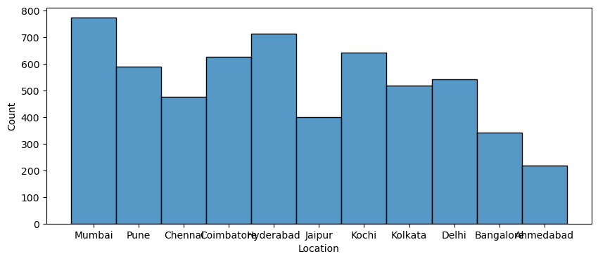

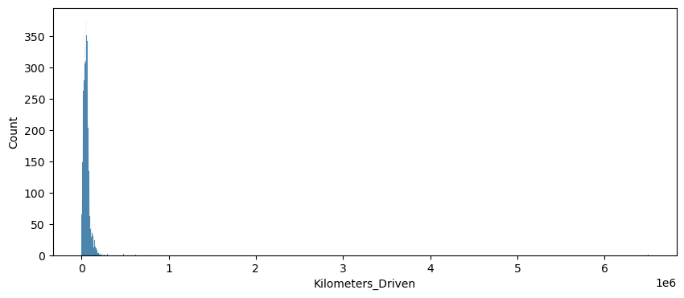

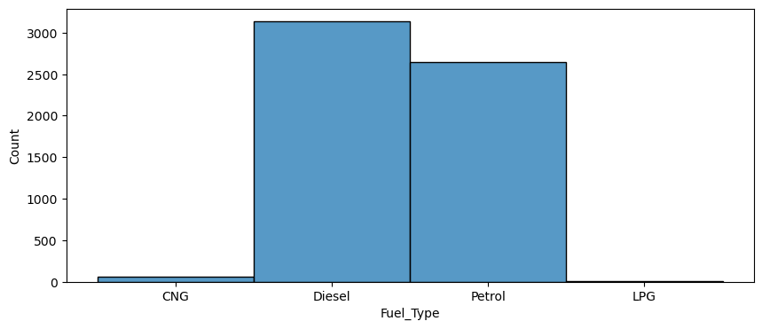

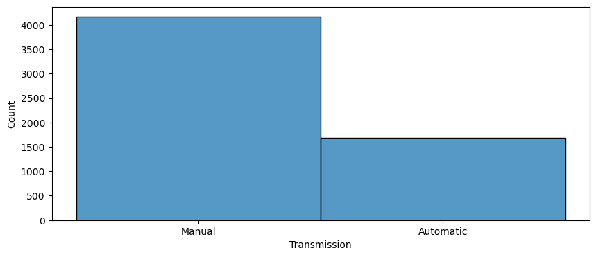

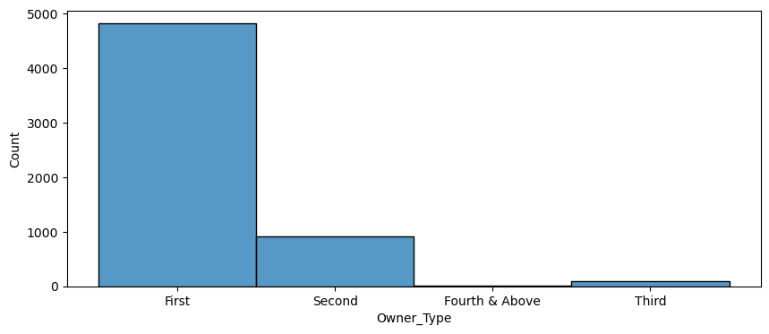

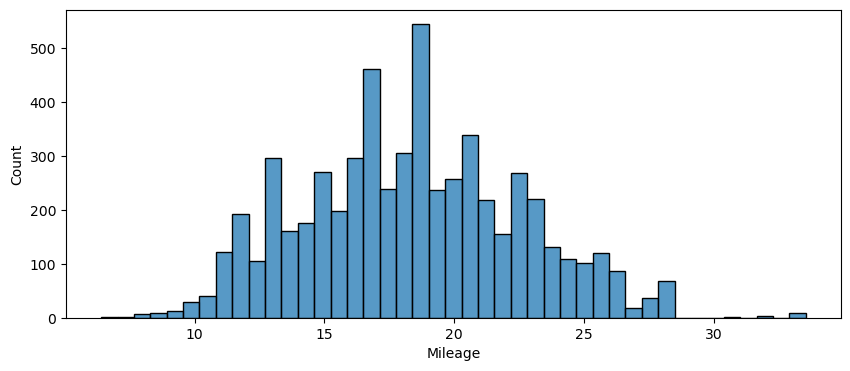

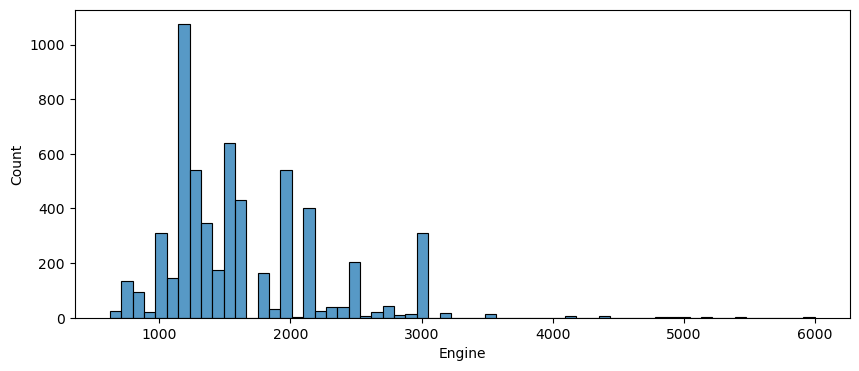

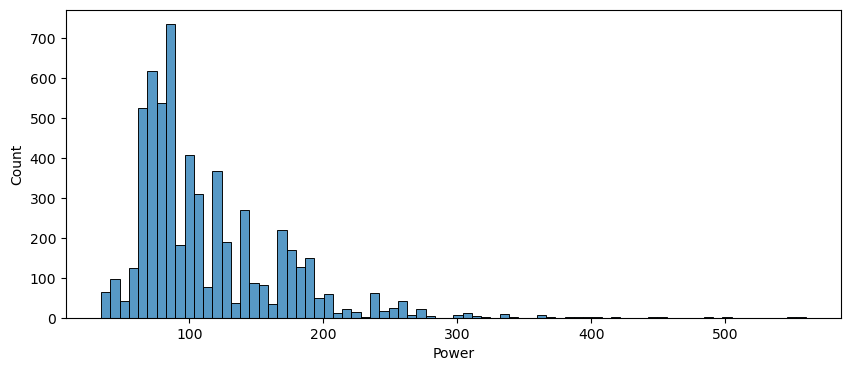

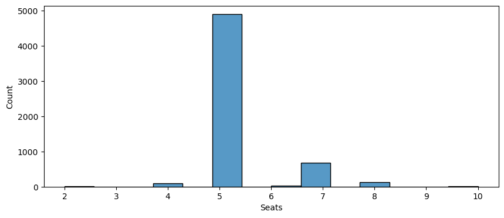

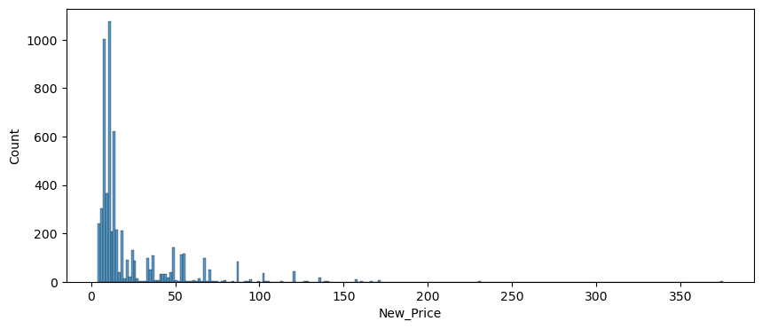

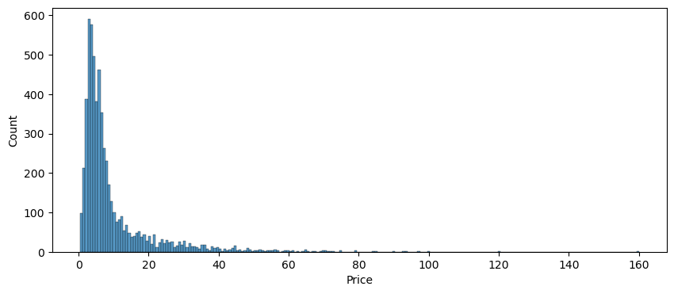

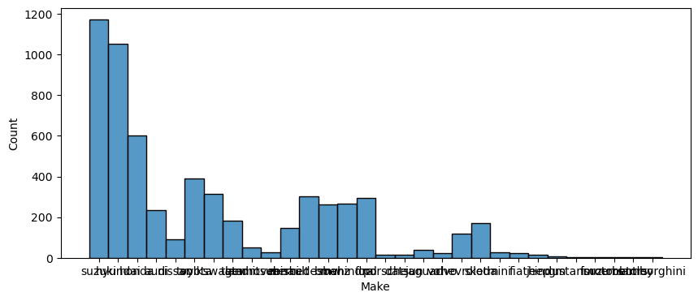

[1 more figures not shown]

```python
#Some univariate analysis
for i in df.columns:
    plt.figure(figsize=(10, 4))
    sns.histplot(data=df, x=i)
    plt.show()
```

Milege is normally distributed. Vehicle age seems somewhat normally distributed.Make,Power, Price appear to be skewed.

```python
for i in df.columns:
    plt.figure(figsize=(10, 10))
    sns.scatterplot(data=df, x=i, y="Price")
    plt.show()
```

[output not shown]

```python
plt.figure(figsize=(15, 7))
sns.heatmap(df.corr(), annot=True, vmin=-1, vmax=1, fmt=".2f", cmap="Spectral")
plt.show()
```

[output not shown]

```python
plt.figure(figsize=(30, 5))
sns.boxplot(x="Make", y="Price", data=df)
plt.show()
```

[output not shown]

```python
plt.figure(figsize=(10, 7))
sns.boxplot(x="Fuel_Type", y="Price", data=df)
plt.show()
```

[output not shown]

```python
plt.figure(figsize=(10, 7))
sns.boxplot(x="Transmission", y="Price", data=df)
plt.show()
```

[output not shown]

```python
Automatic cars are more expensive than manual
```

```python
plt.figure(figsize=(10, 7))
sns.boxplot(x="Owner_Type", y="Price", data=df)
plt.show()
```

[output not shown]

```python
Owner Type seems to have had little effect on the price
```

```python
plt.figure(figsize=(10, 7))
sns.boxplot(x="Location", y="Price", data=df)
plt.show()
```

[output not shown]

# Building a model

```python
#first split the data set
X = df.drop("Price", axis=1)
Y = df["Price"]
```

```python
#create dummy variables
X = pd.get_dummies(X,columns=X.select_dtypes(include=["object"]).columns.tolist(),drop_first=True)
```

```python
# function to compute adjusted R-squared
def adj_r2_score(predictors, targets, predictions):
    r2 = r2_score(targets, predictions)
    n = predictors.shape[0]
    k = predictors.shape[1]
    return 1 - ((1 - r2) * (n - 1) / (n - k - 1))


# function to compute MAPE
def mape_score(targets, predictions):
    return np.mean(np.abs(targets - predictions) / targets) * 100


# function to compute different metrics to check performance of a regression model
def model_performance_regression(model, predictors, target):
    """
    Function to compute different metrics to check regression model performance

    model: regressor
    predictors: independent variables
    target: dependent variable
    """

    # predicting using the independent variables
    pred = model.predict(predictors)

    r2 = r2_score(target, pred)  # to compute R-squared
    adjr2 = adj_r2_score(predictors, target, pred)  # to compute adjusted R-squared
    rmse = np.sqrt(mean_squared_error(target, pred))  # to compute RMSE
    mae = mean_absolute_error(target, pred)  # to compute MAE
    mape = mape_score(target, pred)  # to compute MAPE

    # creating a dataframe of metrics
    df_perf = pd.DataFrame(
        {
            "RMSE": rmse,
            "MAE": mae,
            "R-squared": r2,
            "Adj. R-squared": adjr2,
            "MAPE": mape,
        },
        index=[0],
    )

    return df_perf
```

```python
# Seperate the training data into 70/30 ratio of training to test data

X_train, X_test, y_train, y_test = train_test_split(
    X, Y, test_size=0.30, random_state=1
)

# build the model
regression_model = LinearRegression()
regression_model.fit(X_train, y_train)

#score the models
print(
    "The score (R-squared) on the training set is ",
    regression_model.score(X_train, y_train),
)
# get the score (R-squared) on the test set

print(
    "The score (R-squared) on the test set is ", regression_model.score(X_test, y_test)
)

print("Training Performance\n")
lin_reg_model_train_perf = model_performance_regression(regression_model, X_train, y_train)
lin_reg_model_train_perf
```

[output not shown]

### I want to take the log and x^2 of the dependent variable to see if there are any improvements

```python
Y_square = df['Price'].apply(pow,args=([2]))
# Seperate the training data into 70/30 ratio of training to test data

X_train, X_test, y_train, y_test = train_test_split(
    X, Y_square, test_size=0.30, random_state=1
)

# build the model
regression_model = LinearRegression()
regression_model.fit(X_train, y_train)

print(
    "The score (R-squared) on the training set is ",
    regression_model.score(X_train, y_train),
)
# get the score (R-squared) on the test set

print(
    "The score (R-squared) on the test set is ", regression_model.score(X_test, y_test)
)

lin_reg_model_train_perf = model_performance_regression(regression_model, X_train, y_train)
lin_reg_model_train_perf
```

[output not shown]

```python
Y_log = df['Price'].apply(np.log)

# Seperate the training data into 70/30 ratio of training to test data

X_train, X_test, y_train, y_test = train_test_split(
    X, Y_log, test_size=0.30, random_state=1
)

# build the model
regression_model = LinearRegression()
regression_model.fit(X_train, y_train)

print(
    "The score (R-squared) on the training set is ",
    regression_model.score(X_train, y_train),
)
# get the score (R-squared) on the test set

print(
    "The score (R-squared) on the test set is ", regression_model.score(X_test, y_test)
)

lin_reg_model_train_perf = model_performance_regression(regression_model, X_train, y_train)
lin_reg_model_train_perf
```

[output not shown]

```python
lin_reg_model_train_perf = model_performance_regression(regression_model, X_test, y_test)
lin_reg_model_train_perf
```

[output not shown]

### Observations

The model seems to perform very well.

### Conclusion

By doing various transformations I was able to improve the model.